# tutorial14-networkx

## Tutorial 14: Networks and Algorithms

In this tutorial we use the **networkx** module to work with network/graph objects in Python. To start, read in the modules and get the matplotlib graphics engine running properly (if you have a smaller screen, feel free to adjust the size of the plots).

```python
%matplotlib inline
import matplotlib
import matplotlib.pyplot as plt
import networkx as nx
```

```python
matplotlib.rcParams['figure.figsize'] = (17.0, 9.0)
```

### Graph objects

We'll start by creating and empty graph object `G`. Notice that printing out the object does not show anything particularly interesting.

```python
G = nx.Graph()
G
```

```
<networkx.classes.graph.Graph at 0xa20239cf8>
```

We use the method (a function attached to an object) `add_edge` to add things to the graph. The syntax involves giving the names of two connected edges. Here, I'll make a graph of the three (non-island) countries in North America and connect those that share a border.

```python
G.add_edge("United States", "Canada")
G.add_edge("United States", "Mexico")
```

Nodes are created as needed by the `add_edge` function. We can see them using the `nodes` attribute of `G`:

```python
G.nodes
```

```
NodeView(('United States', 'Canada', 'Mexico'))
```

Similarly, the `edges` attribute shows the two edges in our graph.

```python
G.edges
```

```
EdgeView([('United States', 'Canada'), ('United States', 'Mexico')])
```

#### Plotting the network

We can plot a simple version of the graph using one of several plotting methods. Here, I'll use the `draw_spring` function, which should be good enough for most use cases.

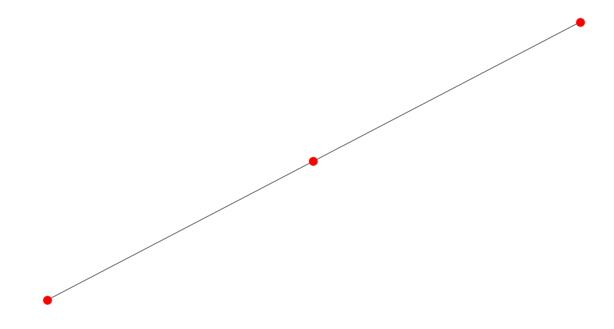

```python
nx.draw_spring(G)
```

**Note: Run the code above a few times and/or look at your neighbors plot. You should see that the results are not stable.** The algorithm is stochastic and based on a physics simulation. The general shape should be similar but the exact output changes each time the code is run.

We can make our plot more interesting using the `with_labels` option.

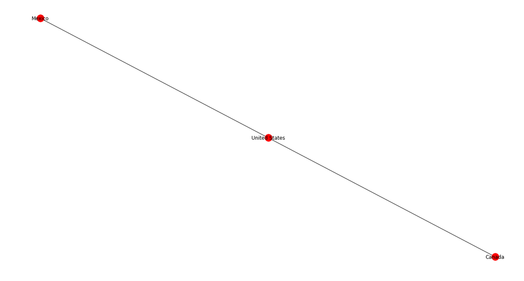

```python
nx.draw_spring(G, with_labels=True)
```

#### A kite graph

Now, let's create a slightly more complex network. This is known as the 'kite graph' given its shape. It is a simplified version of the kite graph from my notes.

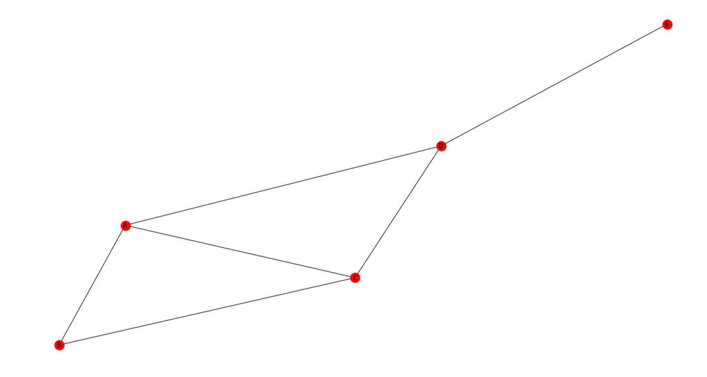

```python
G = nx.Graph()
G.add_edge("A", "B")
G.add_edge("B", "C")
G.add_edge("A", "C")
G.add_edge("C", "D")
G.add_edge("A", "D")
G.add_edge("D", "E")

nx.draw_spring(G, with_labels=True)
```

#### Centrality

Plotting networks is a nice way to start understanding what's going on, but typically more useful in an analysis will be extracting network metrics. For example, we can associate with each node a centrality score.

Eigenvalue centrality scores for each node, $x_j$, are defined through a recursive relationship. Specifically, the eigenvalue centrality of a node is proportional to the sum of its neighbor's, $N(i)$, scores:

$$ x_j = \lambda \cdot \sum_{i \in N(j)} x_i $$

The value of $\lambda$ is an eigenvalue, hence the name (the details are not important right now). We can compute these with the `eigenvector_centrality_numpy` function:

```python
nx.eigenvector_centrality_numpy(G)
```

```
{'A': 0.5370769634854428,
 'B': 0.40669371006285376,
 'C': 0.5370769634854425,
 'D': 0.47474973908441287,
 'E': 0.17974866347516058}
```

For this small example, its easy to see that 'A' and 'C' have the highest score and 'E' the smallest. We can automate this using the code below:

```python
import operator

cent = nx.eigenvector_centrality_numpy(G)
sorted_x = sorted(cent.items(), key=operator.itemgetter(1), reverse=True)
sorted_x
```

```
[('C', 0.5370769634854425),
 ('A', 0.5370769634854424),
 ('D', 0.47474973908441304),
 ('B', 0.406693710062854),
 ('E', 0.1797486634751605)]
```

This will be useful for larger networks. Another, simplier, metric for determining the centrality of a node is the "degree centrality". It's proportional to the number of neighbors a node has.

```python
cent = nx.degree_centrality(G)
sorted_x = sorted(cent.items(), key=operator.itemgetter(1), reverse=True)
sorted_x
```

```
[('A', 0.75), ('C', 0.75), ('D', 0.75), ('B', 0.5), ('E', 0.25)]
```

There are a few other centrality metrics that we saw in the notes, such as betweeness, but I find computing them in **networkx** prohibitively slow.

#### Communities

Another algorithm we can apply to a graph determines what the communities are within the network. Roughly, a community is a set of nodes that are more connected with each other than they are with the remainer of the plot.

Here, we use the `asyn_fluidc` function to split the graph into 3 communities. Note that this algorithm is stochastic and you may have different results each time you run the code.

```python
from networkx.algorithms.community.asyn_fluidc import asyn_fluidc

communities = list(asyn_fluidc(G, 3))
communities
```

```
[{'C'}, {'A', 'B'}, {'D', 'E'}]
```

While we have this small example, let' see how to inverse this process by assigning each node to its cluster.

```python
communities_id = {}
for idx, val in enumerate(communities):
    for k in val:
        communities_id[k] = idx

communities_id
```

```
{'C': 0, 'A': 1, 'B': 1, 'D': 2, 'E': 2}
```

```python
import pandas as pd
df = pd.DataFrame(dict(title=list(communities_id.keys()),
                       community=list(communities_id.values())))
df = df.sort_values('title')
df = df.reset_index(drop=True)
df
```

|  | title | community |
| --- | --- | --- |
| 0 | A | 1 |
| 1 | B | 1 |
| 2 | C | 0 |
| 3 | D | 2 |
| 4 | E | 2 |

This will be useful in our next set of notes.

### Wikipedia graphs

Now, let's build some more interesting graphs using our Wikipedia corpus. Start by loading in the `iplot` and `wiki` modules.

```python
import iplot
import wiki

assert iplot.__version__ >= 1
assert wiki.__version__ >= 3
```

We'll work with the Birthday Cake dataset first. Here is the data to get all of the pages linked to from the seed page:

```python
data_json = wiki.get_wiki_json("Birthday_cake")
internal_links = wiki.links_as_list(data_json) + ['Birthday_cake']
internal_links[:10]
```

```
['Atlantic magazine',
 'The Independent',
 'Tteok',
 'Ancient Rome',
 'Angel cake',
 'Angel food cake',
 'Apple cake',
 'Avocado cake',
 'Babka (cake)',
 'Banana bread']
```

Now, we want to create a graph object where the nodes are the pages stored in `internal_links` and edges connect any two pages that link to one another. How would we go about doing this? We will need a `for` loop to cycle through the pages. But, on each page we **also** need to cycle through all of internal links on that page. To do this, we'll need *nested loops*. That is, we have one loop inside of another.

Here is an example of how a nested for loop works. To show this, I'll create an object `A` that consists of a "list of lists":

```python
A = [['cow', 'chicken', 'duck'], ['banana', 'apple'], ['Virginia', 'Maryland']]

for items in A:
    for x in items:
        print(x + ' - ' + str(len(x)))
```

```
cow - 3
chicken - 7
duck - 4
banana - 6
apple - 5
Virginia - 8
Maryland - 8
```

So, there isn't too much to the nested for loops. Now, try to use everything we've learned to fix the code below to create a graph of all the internal links on the pages in the list `internal_links`. (Note: the resulting graph is probably not exactly what we need, more on this below).

```python
G = nx.Graph()

for link in internal_links:
    data = wiki.get_wiki_json(link)
    for new_link in data['links']:
        G.add_edge(link, new_link['*'])
```

Now, how many edges are there in the graph?

```python
len(G.edges)
```

```
48136
```

You should have thousands of edges. If you only have a few hundred, you didn't do the nested loops correctly.

Let's now see how many nodes there are in the graph:

```python
len(G.nodes)
```

```
17051
```

Compare this with the number of internal links:

```python
len(internal_links)
```

```
203
```

Unless you did something wrong (or very clever) above, you should see that there are over 15k nodes in the graph even though there are 203 internal links.

**Question: Why is there this discrepency? (and if you somehow took care of the issue already, try to think of what problem would cause someone to have too many nodes)**

**Answer:** We are accidentally including *all* internal links, not just links to pages in our original set `internal_links`. We need to make sure that only these edges are included in the graph.

### Testing inclusion

I'll give you the answer to the question directly above: you probably included all of the internal links on all of the pages. This would include, for example, any link on any page linked to from the Birthday Cake page. We don't want all of these links. Instead, we only want links where the starting and ending node are in our set `internal_links`.

Here, I'll walk you through two different ways to do this in Python using one page as an example. You'll then work one of these methods into your nested loop.

Let's take the 18th internal link, which should be the 'Birthday':

```python
link = internal_links[17]
link
```

```
'Birthday'
```

I'll grab the JSON file for this page and extract its internal links:

```python
data = wiki.get_wiki_json(link)
new_links = wiki.links_as_list(data)
new_links[:25]
```

```
['ABC News',
 'Age of consent',
 'Age of majority',
 'Age of marriage',
 'Anniversary',
 'Anzac Day',
 'Australia',
 'Bar mitzvah',
 'Bat mitzvah',
 'Birth',
 'Birth certificate',
 'Birthday (disambiguation)',
 'Birthday attack',
 'Birthday card',
 'Birthday paradox',
 'Birthday party',
 'Birthstones',
 'British Royal Family',
 'Buddha',
 "Buddha's Birthday",
 "Buddha's birthday",
 'Caesarean section',
 'Cake',
 'Canada',
 'Canterbury Tales']
```

Many, perhaps even most, of these links are **not** in our set `internal_links`. We want to filter out only those that are. There are two ways to do this, and I will show you both.

The first method uses the function `set` to create a set object in Python. A set is similar to a list, but cannot contain any duplicate values and does not have any particular ordering. Sets in python allow for set arthimetic, so if we subtract one set from another it will remove elements in the second from the first. For example:

```python
set(['a', 'b', 'c', 'd']) - set(['b', 'c'])
```

```
{'a', 'd'}
```

Similarly, the `intersection` method of a set find those elements that are common between to sets:

```python
set(['a', 'b', 'c', 'd']).intersection(set(['b', 'c']))
```

```
{'b', 'c'}
```

```python
list(set(new_links).intersection(set(internal_links)))
```

```
['Cake', 'Happy Birthday to You', 'Rite of passage']
```

You should see that it have just three links to other pages in our set.

The other way to solve this problem is to test whether a specific link is in our list `internal_links`. This can be done with the function `in` for a particular element:

```python
'Cake' in internal_links
```

```
True
```

```python
'Age of marriage' in internal_links
```

```
False
```

How do we make use of this? We can use an `if` statement which executes its code only if a statement is `True`. So:

```python
for link in new_links:
    if link in internal_links:
        print(link)
```

```
Cake
Happy Birthday to You
Rite of passage
```

Either way works for this application. The sets are a bit cleaner, but we'll need `if` statements in other applications so it's useful to see how they work here.

### Wikipedia graphs II

Now that we know how to only include the correct edges, here we will write code here to create the correct graph. It will be more interesting to work with the Richmond dataset in our analysis, so let's use that one now.

```python
data_json = wiki.get_wiki_json("Richmond, Virginia")
internal_links = wiki.links_as_list(data_json) + ['Richmond, Virginia']
```

Now, write the code for constructing the graph here:

```python
G = nx.Graph()

for link in internal_links:
    data = wiki.get_wiki_json(link)
    for new_link in data['links']:
        if new_link['*'] in internal_links:
            G.add_edge(link, new_link['*'])
```

When you're done, test that it has as many nodes as there are internal links.

```python
print(len(G.nodes))
print(len(internal_links))
```

```
1130
1131
```

**Note:** There is one more internal link because we have a duplicate in the dataset. I manually added a link to 'Richmond, Virgina', but the page already cites itself. This will not effect our analysis.

### Analysis

Now, finally, let's actually analyze our data using the `networkx` module. To start, try to plot the network (it's possible that this will be too slow on your machine, just try it out anyway).

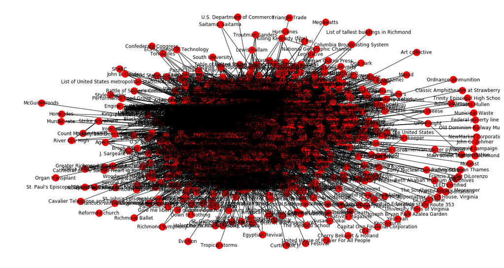

```python
nx.draw_spring(G, with_labels=True)
```

The plot here is very difficult to read, and won't be very helpful for our analysis. A better approach is to use the network structure to tell use something about the structure of the internal links on Wikipedia.

In this code here, copy the code from above to compute the eigenvector centrality score and print out the top pages.

```python
import operator

cent = nx.eigenvector_centrality_numpy(G)
sorted_x = sorted(cent.items(), key=operator.itemgetter(1), reverse=True)
sorted_x[:20]
```

```
[('Richmond, Virginia', 0.08268749738463398),
 ('Virginia', 0.07619235510697321),
 ('Norfolk, Virginia', 0.06989990000333823),
 ('Petersburg, Virginia', 0.0688870435560129),
 ('Chesterfield County, Virginia', 0.06840425092536104),
 ('Virginia Beach, Virginia', 0.06832816054091058),
 ('Henrico County, Virginia', 0.06814254550426956),
 ('Alexandria, Virginia', 0.06799634882780073),
 ('Lynchburg, Virginia', 0.06795528750079156),
 ('Williamsburg, Virginia', 0.0678764965285787),
 ('Powhatan County, Virginia', 0.0677643862667715),
 ('Hanover County, Virginia', 0.06775933954491575),
 ('Charles City County, Virginia', 0.06771719798959172),
 ('Caroline County, Virginia', 0.06757062211920935),
 ('Prince George County, Virginia', 0.06744890737289008),
 ('New Kent County, Virginia', 0.06740607133301774),
 ('Hampton, Virginia', 0.06725303835781346),
 ('Fredericksburg, Virginia', 0.06724407122625331),
 ('Louisa County, Virginia', 0.0672317289172287),
 ('King William County, Virginia', 0.06720329738893888)]
```

**Question**: What do you notice about the top pages? Any guess as to why these have the highest centrality scores?

**Answer**: These are all other nearby cities and counties. It makes sense that these pages would have a similar set of links to those on the Richmond site.

Let's also look at some of the communities found by the network algorithm. Detect 25 communities using the Fluid Communities algorithm. I've set the *random seed* here so that the results should be the same for everyone (the algorithm is stochastic and will give slightly different results each time you run it).

```python
import random
random.seed(1)

communities = list(asyn_fluidc(G, 25))
```

The code below prints out pages in each of the 25 communities.

```python
for idx, com in enumerate(communities):
    print(str(idx) + ":")
    print("; ".join(list(com)))
    print("")
```

```
0:
Northern Mariana Islands; Wyoming; Columbia, South Carolina; 1880 United States Census; Wisconsin; New York (state); Charleston, West Virginia; Atlanta; 1930 United States Census; Washington (state); Bibliothèque nationale de France; United States Census Bureau; Native Americans in the United States…

1:
Ginter Park; The Shops at Willow Lawn; Main Street Banking Historic District; Monroe Ward; Fairmount, Richmond, Virginia; Pine Camp, Richmond, Virginia; Sauer's Gardens; Lockgreen; Virginia Museum of Fine Arts; Green Park, Richmond, Virginia; Geographic coordinate system; Chinatown, Richmond; Washin…

2:
Maggie L. Walker; The West End (Richmond, Virginia); Maggie L. Walker Governor's School for Government and International Studies; Richmond Public Schools; Richmond-Petersburg; Richmond Free Press; United States Court of Appeals for the Fourth Circuit; African-American; Henry L. Marsh; Visual Arts Ce…

3:
Claudia Emerson; AMC (TV channel); Major League Baseball; Jefferson Hotel (Richmond, Virginia); International Standard Name Identifier; Vince Gilligan; San Francisco Giants; William Mayo (civil engineer); Virginius Dabney; James Branch Cabell; Minor league; Training camp (National Football League); …

4:
Darrell Waltrip; Southeastern United States; Legislative; NASCAR; Iraq War; Virginia War Memorial; Federal Reserve System; Monster Energy NASCAR Cup Series; Tornadoes; Southside Speedway; Morgan Quitno Press; Monster Energy; War in Afghanistan (2001–present); Vietnam War; Gulf War; Mississippi River…

5:
United States presidential election in Virginia, 1944; United States presidential election in Virginia, 1916; United States presidential election in Virginia, 1928; United States presidential election in Virginia, 1988; United States presidential election in Virginia, 2008; United States presidentia…

6:
Gas lighting; WRLH-TV; Charleston, South Carolina; WRIC-TV; American Broadcasting Company; WTVR-TV; Departures (magazine); PBS; Lewis Hallam; NBC; Low-power broadcasting; 1 E+8 m²; Talk radio; WCVE-TV; Southern Living; Virginia College; Media General; Southside Baptist Christian School; College bask…

7:
Carpenter Theater; Cast-iron architecture; Art Deco; Minoru Yamasaki; Beaux-Arts architecture; Architectural firm; Greek Revival architecture; Neoclassicism; CTI Consultants; West Franklin Street Historic District; Neoclassical architecture; Henry Coalter Cabell House; Movie palace; Science Museum o…

8:
Dave Smith (poet); Liquor; SunTrust Banks; Atlanta, Georgia; Rock climbing; Virginia Repertory Theatre; Denali; Pastrami; Kathleen Graber; Broadside; Mustard (condiment); Troutman Sanders; T. R. Hummer; Sailor sandwich; Anna Journey; Distillation; Rye bread; Busch Gardens; Ségou; South University; P…

9:
Stony Point Fashion Park; Barret House (Richmond, Virginia); Hurricane Connie; Hurricane Diane; Church Hill, Richmond, Virginia; RVA Magazine; Lincoln (2012 film); Short Pump Town Center; Broad Street (Richmond, Virginia); Broad Street Station (Richmond); History of Richmond, Virginia; Branch House;…

10:
YouTube; Eric Stanley (violinist); Foodie; Count Me Out (band); Stuart C. Siegel Center; River City High; Amazon.com; Altria Theater; The Martin Agency; Carbon Leaf; GWAR; D'Angelo; Steven Holl; Institute for Contemporary Art, Richmond; Alabama Thunderpussy; National Theater (Richmond, Virginia); La…

11:
Genworth Financial; Killing Kennedy (film); Collegiate School (Richmond, Virginia); Sparklehorse; Sarah Schkeeper; New York Times; Chris Brown; Arthur Ashe; White House; Tom Wolfe; MSNBC; Tennis; David Baldacci; St. Christopher's School, Richmond; Rob Lowe; Street art; United States Tennis Associati…

12:
Gloucester County, Virginia; Tri-Cities, Virginia; Mathews County, Virginia; Lynchburg, Virginia; Fairfax County, Virginia; Music of Virginia; Hanover County, Virginia; Colonial Heights, Virginia; Native American tribes in Virginia; Russell County, Virginia; Franklin County, Virginia; Salem, Virgini…

13:
```

[output cut: 19 more lines]

```

20:
McKesson Corporation; Pendlebury; River Thames; Microbrewery; Richmond Hill, London; Richard Neutra; Lancashire; David L. Robbins (Virginia writer); Agecroft Hall; Opera house; Tudor period; Urban renewal; Richmond, North Yorkshire; London; Dean King; Richmond, London; Daniel Day-Lewis; Philip Johns…

21:
Style Weekly; Dominion Energy; Owens & Minor; North Anna Nuclear Generating Station; Powhatan Confederacy; CarMax; List of cities in Virginia; Fortune 500; Surry Nuclear Generating Station; The Virginian-Pilot; Virginia Opera; Dominion Resources

22:
St. Catherine's School, Richmond, Virginia; Valentine Richmond History Center; Woodward House (Richmond, Virginia); Edgar Allan Poe Museum (Richmond, Virginia); Taylor-Mayo House; St. Paul's Episcopal Church (Richmond, Virginia); Edgar Allan Poe Museum (Richmond); Grace Street Commercial Historic Di…

23:
Precipitation (meteorology); Mother church; Charter school; Saitama, Saitama; Windhoek; MarketWatch; Zhengzhou; Middle school; Freezing rain; Philadelphia, Pennsylvania; The CW Television Network; I.M. Pei; Seminary; Pacific Islands American

24:
Brook Road Academy; Egyptian Revival; Main Street Station (Richmond, Virginia); Harvard Five; Peninsula campaign; Aditya Birla Minacs; French Film Festival; Knockwurst; Homicides; Landis Gores; Organ transplant; Classic Amphitheatre at Strawberry Hill; Transit (transportation); List of tallest build…
```

Look at the communities and try to figure out what each represents. Assuming that the seed works the same on your machine as it does mine, you should be able to figure out at least what communities 1, 3, 5, 6, 7, 8, 9, 10 11, 12, and 15 are clustering around.

### Aggregating

For the first project, you are writing code that pulls a number of page metrics and puts them all into a pandas DataFrame. We can similarly put network metrics into a DataFrame object. I'll just give you the code here for collecting the eigenvector and degree centrality scores.

```python
import pandas as pd

df = pd.DataFrame(dict(
    eigen=nx.eigenvector_centrality_numpy(G),
    degree=nx.degree_centrality(G)
))
df['title'] = df.index
df['url'] = df.index
```

```python
df.head()
```

|  | eigen | degree | title | url |
| --- | --- | --- | --- | --- |
| 1 E+8 m² | 0.002388 | 0.018601 | 1 E+8 m² | 1 E+8 m² |
| 1708 Gallery | 0.000399 | 0.004429 | 1708 Gallery | 1708 Gallery |
| 1790 United States Census | 0.026604 | 0.113375 | 1790 United States Census | 1790 United States Census |
| 1800 United States Census | 0.029874 | 0.128432 | 1800 United States Census | 1800 United States Census |
| 1810 United States Census | 0.031090 | 0.137290 | 1810 United States Census | 1810 United States Census |

Now, I'll use the `iplot` module to create a visualization of this data.

```python
p = iplot.create_figure(df, 'eigen', 'degree', color='eigen', url='url')
iplot.show(p)
```

[interactive chart not shown]

We can also add page metrics to the DataFrame, such as the total length of the page.

```python
page_len = []
for link in df['title']:
    try:
        data = wiki.get_wiki_json(link)
        page_len.append(len(data['text']['*']))
    except:
        page_len.append(0)


df['page_len'] = page_len
```

I'll make another plot that shows the page length as a function of the eigenvalue centrality.

```python
p = iplot.create_figure(df, 'eigen', 'page_len', color='degree', url='url')
iplot.show(p)
```

[interactive chart not shown]

Answer the questions below using the interactive plots (it will also require some thinking!).

**Question:** You should find that Richmond, Virginia has the highest eigenvalue and degree centrality. This is not surprising because by definition it's connected to every other page. There should be four other pages that have particularly high degree centralities. Look at them on the first plot; why do these have a high degree value?

**Answer:** The other four are: 'Virginia', 'United States', 'Geographic coordinate system', and 'International Standard Book Number'. The latter is linked to from any page that includes a book reference and 'Geographic coordinate system' is included on any page with geographic information (e.g., states, cities, counties). The first two are high because they are included in nearly any page about a location in Richmond or nearby city/county.

**Question:** On the first plot, you should see that the counties clump together, the neighborhoods clump together, and the states clump together. Describe briefly where each of these are on the plot.

**Answer:** The counties have some of the highest eigenvalue scores, and large (but not much larger than many other pages) degree centralities. That is, they have a good number of links, but more importantly the links are to highly linked pages (such as 'Virginia, 'United States', 'Geographic coordinate system', and 'ISBN').

The neighborhoods have fairly low eigenvalue scores but higher degree centralities than other pages with similar eigenvalue scores.

**Question:** On the second plot, describe a few pages that are very long but have a low eigenvector centrality. Why do you think this is the case?

**Answer:** Long pages that have a low centrality score tend to be about something that is not directly related to Richmond, such as 'Vietnam War', 'War in Afganistan', 'Hinduism', and 'London'. These pages would likely have a high centrality over the entire Wikipedia corpus, but just do not connect very strongly to this particular set.

**Question:** On the second plot, describe a few pages that have a high centrality score but are relatively short. What's going on here?

**Answer:** Pages for small Virginia counties tend to be short but have a high centrality score because they link to other county pages (which are highly connected) and to the important pages such as 'Geographic coordinate system', 'Virginia', and 'United States'.